# MBS Model Monitoring Report (Repeat/Top Up)

June 10, 2025

# Executive Summary

This document provides model monitoring analysis for the MBS Model (REPEAT + TOPUP). The report analyzes model performance stability, feature drift, and business implications by comparing the current production data with the development sample.

**Key Information:**

- **Development sample period:** March’23 - November’23
- **Current monitoring period:** December’24 - March’25
- **Training target:** 20+ Ever in 120 Days
- **Testing target:** 10+ Ever in 90 Days

> Testing target is different from training target due data insufficiency and hence results are not reflective of true performance.

```r
# User Configuration - Modify these parameters
data_path <- "../../model_monitoring_out_mbs_repeat_topup.csv"
reference_data_path <- "repeat_topup_final_modelling_dataset.csv"
model_file <- "mbs_repeat_topup_final_model.RDS"

# Common configuration
target_var <- "target"
pred_var <- "predicted"

# List of features to be analysed
features_to_analyze <- c(
  'speaker_vintage',
  'total_active_vintage',
  'active_days_ratio_working_hour',
  'rsd_txn',
  'txn_per_active_day_non_working_hour',
  'dist_diff_metres_onboarding_lending_geohash',
  'active_days_ratio_0_30_qr',
  'vintage',
  'active_days_ratio_0_30_working_hour',
  'rsd_sum_tpv',
  'unique_txn_per_active_day',
  'days_active_ratio',
  'self_tpv_ratio_qr',
  'total_applications',
  'avg_ticket_value_30_60_qr',
  'avg_ticket_value_qr',
  'geo_risk',
  'shift_txn_m1_m2',
  'shift_txn_m1_m3',
  'active_days_ratio_0_30',
  'app_approval_rate_12m'
)
```

```r
pacman::p_load(
  "tidyverse",
  "plotly",
  "DT",
  "pROC",
  "ROCR",
  "scales",
  "gridExtra",
  "reshape2",
  "caret",
  "e1071",
  "kableExtra",
  "data.table",
  "magrittr",
  "patchwork",
  "lubridate"
)

# Source helper functions
source("helper_functions_MBS.R")
```

```r
# Load data using data.table for better performance
current_data <- fread(data_path, showProgress = FALSE)
reference_data <- fread(reference_data_path, showProgress = FALSE)
mdl <- readRDS(model_file)

# Create target flag
reference_data$target <- reference_data$flag

# Validate predictions are numeric and finite
# Get actual predictions using model file if needed
current_predictions <- current_data[[pred_var]]
current_data$predicted <- current_predictions

vars <- mdl$feature_names
pred_df <- reference_data %>% select(!!vars)
# pred_df[is.na(pred_df)] <- -999999
pred_df <- as.matrix(pred_df)
reference_predictions <- predict(mdl, newdata = pred_df)
```

[output not shown]

```r
reference_data$predicted <- reference_predictions

# Lower colnames
colnames(reference_data) <- tolower(colnames(reference_data))

# Validate features exist in both data sets
missing_current <- setdiff(features_to_analyze, names(current_data))
missing_reference <- setdiff(features_to_analyze, names(reference_data))

if (length(missing_current) | length(missing_reference) > 0) {
  stop("Missing features")
}

# Extract relevant columns
# current_features <- current_data[, ..features_to_analyze]
# reference_features <- reference_data[, ..features_to_analyze]

# Validate target is numeric
current_target <- current_data[[target_var]]
reference_target <- reference_data[[target_var]]

data.frame(
  Metric = c("Data samples", "Data samples", "Target rate", "Target rate"),
  Dataset = c("Current", "Reference", "Current", "Reference"),
  Value = c(
    nrow(current_data),
    nrow(reference_data),
    sprintf("%.1f%%", mean(current_target, na.rm = TRUE) * 100),
    sprintf("%.1f%%", mean(reference_target, na.rm = TRUE) * 100)
  )
) %>% datatable()
```

|  | Metric | Dataset | Value |
| --- | --- | --- | --- |
| 1 | Data samples | Current | 48588 |
| 2 | Data samples | Reference | 301983 |
| 3 | Target rate | Current | 4.5% |
| 4 | Target rate | Reference | 7.4% |

# Data Quality Analysis

Data quality is a critical foundation for reliable model monitoring. Poor data quality can lead to misleading conclusions about model performance and stability. This section examines three key aspects of data quality that could impact model performance:

1. **Missing Values**: Significant shifts in missing value patterns may indicate data collection issues, process changes, or population shifts
2. **Zero Values**: Changes in the frequency of zero values can signal data quality issues or genuine shifts in customer behavior
3. **Outliers**: Variations in outlier prevalence may indicate data quality problems or changes in the underlying population

Each analysis includes color-coded highlighting to quickly identify areas of concern:

- **Green/White**: Minimal change, no action required
- **Yellow**: Moderate change, requires monitoring
- **Red**: Significant change, requires investigation

The Data Shift Summary provides an aggregate quality score that combines these metrics to prioritize variables requiring attention.

## Missing Values Analysis

Significant difference in missing values across development and validation samples could point towards:

- Data issues
- Potential changes in sourcing quality

Missing values should be handled appropriately and not always encoded as zeros during development/testing.

```r
# Calculate missing values for each feature
missing_values <- data.frame(
  Feature = features_to_analyze,
  Current_Missing_Pct = NA,
  Reference_Missing_Pct = NA
)

for (feature_name in features_to_analyze) {
  missing_pcts <- check_missing_values(feature_name)
  missing_values$Current_Missing_Pct[missing_values$Feature == feature_name] <- missing_pcts[1]
  missing_values$Reference_Missing_Pct[missing_values$Feature == feature_name] <- missing_pcts[2]
}

# Add highlighting for significant changes in missing values
datatable(
  missing_values %>%
    arrange(desc(Current_Missing_Pct)),
  options = list(pageLength = 10)
) %>%
  formatPercentage(columns = c("Current_Missing_Pct", "Reference_Missing_Pct"), digits = 1) %>%
  formatStyle(
    columns = c("Current_Missing_Pct", "Reference_Missing_Pct"),
    backgroundColor = styleInterval(c(0.05, 0.2), c("white", "#fff3cd", "#f8d7da"))
  )
```

|  | Feature | Current_Missing_Pct | Reference_Missing_Pct |
| --- | --- | --- | --- |
| 1 | txn_per_active_day_non_working_hour | 0.1755989133119289 | 0 |
| 2 | app_approval_rate_12m | 0.1306083806701243 | 0 |
| 3 | rsd_txn | 0.02971927224829176 | 0 |
| 4 | rsd_sum_tpv | 0.02971927224829176 | 0 |
| 5 | unique_txn_per_active_day | 0.02971927224829176 | 0 |
| 6 | shift_txn_m1_m3 | 0.0226393348151807 | 0 |
| 7 | avg_ticket_value_30_60_qr | 0.01905820367168848 | 0 |
| 8 | shift_txn_m1_m2 | 0.01895529760434675 | 0 |
| 9 | geo_risk | 0.01029060673417305 | 0 |
| 10 | total_applications | 0.005392277928706677 | 0 |

[output cut: 11 more lines]

## Zero Values Analysis

Significant difference in percentage of zero-values across development and validation samples could point towards:

- Data issues
- Potential changes in sourcing quality

```r
# Calculate zero value percentages for each feature
zero_values <- data.frame(
  Feature = features_to_analyze,
  Current_Zero_Pct = NA,
  Reference_Zero_Pct = NA
)

for (feature_name in features_to_analyze) {
  zero_pcts <- check_zero_values(feature_name)
  zero_values$Current_Zero_Pct[zero_values$Feature == feature_name] <- zero_pcts[1]
  zero_values$Reference_Zero_Pct[zero_values$Feature == feature_name] <- zero_pcts[2]
}

zero_values %<>% mutate(diff = abs(Current_Zero_Pct - Reference_Zero_Pct))

# Add highlighting for high percentages of zero values
datatable(
  zero_values %>%
    arrange(desc(diff)),
  options = list(pageLength = 10)
) %>%
  formatPercentage(columns = c("Current_Zero_Pct", "Reference_Zero_Pct", "diff"), digits = 2) %>%
  formatStyle(
    columns = c("diff"),
    backgroundColor = styleInterval(c(0.05, 0.2), c("white", "#fff3cd", "#f8d7da"))
  )
```

|  | Feature | Current_Zero_Pct | Reference_Zero_Pct | diff |
| --- | --- | --- | --- | --- |
| 1 | dist_diff_metres_onboarding_lending_geohash | 1 | 0.7960083845779398 | 0.2039916154220602 |
| 2 | speaker_vintage | 0.773606651848193 | 0.5788239735349341 | 0.1947826783132589 |
| 3 | self_tpv_ratio_qr | 0.66388820284844 | 0.4851994979849859 | 0.1786887048634541 |
| 4 | geo_risk | 0.08090475014406849 | 0 | 0.08090475014406849 |
| 5 | app_approval_rate_12m | 0.06427512966164485 | 0.05194000986810516 | 0.01233511979353969 |
| 6 | shift_txn_m1_m2 | 0.01907878488515683 | 0.01389482189394767 | 0.005183962991209155 |
| 7 | shift_txn_m1_m3 | 0.01564172223594303 | 0.01108671680193918 | 0.004555005434003851 |
| 8 | rsd_txn | 0.001564172223594303 | 0 | 0.001564172223594303 |
| 9 | rsd_sum_tpv | 0.0008438297522021898 | 0 | 0.0008438297522021898 |
| 10 | days_active_ratio | 0.0003087182020251914 | 0 | 0.0003087182020251914 |

[output cut: 11 more lines]

## Outlier Analysis

Higher percentage of outliers typically indicate a skew. Depending on the attribute, this could indicate a shift towards better(or worse) sourcing quality. Here, outliers are detected using the inter-quartile method and the percentage of outliers between current and reference datasets are compared.

> Note that during training, null values were replaced by -999999

```r
# Calculate outlier percentages for each feature
outlier_values <- data.frame(
  Feature = features_to_analyze,
  Current_Outlier_Pct = NA,
  Reference_Outlier_Pct = NA
)

for (feature_name in features_to_analyze) {
  outlier_pcts <- check_outliers(feature_name)
  outlier_values$Current_Outlier_Pct[outlier_values$Feature == feature_name] <- outlier_pcts[1]
  outlier_values$Reference_Outlier_Pct[outlier_values$Feature == feature_name] <- outlier_pcts[2]
}

outlier_values %<>%
  mutate(diff = abs(Current_Outlier_Pct - Reference_Outlier_Pct))

# Add highlighting for high percentages of outliers
datatable(
  outlier_values %>%
    arrange(desc(diff)),
  options = list(pageLength = 10)
) %>%
  formatPercentage(columns = c("Current_Outlier_Pct", "Reference_Outlier_Pct", "diff"), digits = 2) %>%
  formatStyle(
    columns = c("diff"),
    backgroundColor = styleInterval(c(0.05, 0.2), c("white", "#fff3cd", "#f8d7da"))
  )
```

|  | Feature | Current_Outlier_Pct | Reference_Outlier_Pct | diff |
| --- | --- | --- | --- | --- |
| 1 | dist_diff_metres_onboarding_lending_geohash | 0 | 0.2039916154220602 | 0.2039916154220602 |
| 2 | speaker_vintage | 0.226393348151807 | 0.03912140749644848 | 0.1872719406553586 |
| 3 | txn_per_active_day_non_working_hour | 0.1006421338602124 | 0.2783368600219218 | 0.1776947261617094 |
| 4 | app_approval_rate_12m | 0 | 0.0925118301361335 | 0.0925118301361335 |
| 5 | geo_risk | 0.01413929365275377 | 0.1001182185752178 | 0.08597892492246405 |
| 6 | shift_txn_m1_m3 | 0.06108504157405121 | 0.1347261269674121 | 0.07364108539336087 |
| 7 | shift_txn_m1_m2 | 0.05678356795916687 | 0.1251891662775719 | 0.06840559831840506 |
| 8 | active_days_ratio_working_hour | 0.07950522762822096 | 0.02497491580651891 | 0.05453031182170205 |
| 9 | active_days_ratio_0_30 | 0.08621470321890179 | 0.03373699844030956 | 0.05247770477859223 |
| 10 | active_days_ratio_0_30_qr | 0.0889931670371285 | 0.03949560074573735 | 0.04949756629139116 |

[output cut: 11 more lines]

## Data Shift Summary

```r
# Create summary of data quality issues
quality_summary <- data.frame(
  Feature = features_to_analyze,
  Missing_Value_Change = abs(missing_values$Current_Missing_Pct - missing_values$Reference_Missing_Pct),
  Zero_Value_Change = abs(zero_values$Current_Zero_Pct - zero_values$Reference_Zero_Pct),
  Outlier_Change = abs(outlier_values$Current_Outlier_Pct - outlier_values$Reference_Outlier_Pct)
)

quality_summary$Quality_Score <- 100 - (
  quality_summary$Missing_Value_Change * 100 +
    quality_summary$Zero_Value_Change * 100 * 0.5 +
    quality_summary$Outlier_Change * 100
)

quality_summary$Quality_Status <- case_when(
  quality_summary$Quality_Score >= 90 ~ "Good",
  quality_summary$Quality_Score >= 70 ~ "Warning",
  TRUE ~ "Poor"
)

datatable(
  quality_summary %>%
    arrange(Quality_Score),
  options = list(pageLength = 10)
) %>%
  formatPercentage(columns = c(
    "Missing_Value_Change",
    "Zero_Value_Change",
    "Outlier_Change"
  ), digits = 2) %>%
  formatRound(columns = "Quality_Score", digits = 0) %>%
  formatStyle("Quality_Status",
              backgroundColor = styleEqual(
                c("Good", "Warning", "Poor"),
                c("#d4edda", "#fff3cd", "#f8d7da")
              )
  )
```

|  | Feature | Missing_Value_Change | Zero_Value_Change | Outlier_Change | Quality_Score | Quality_Status |
| --- | --- | --- | --- | --- | --- | --- |
| 1 | txn_per_active_day_non_working_hour | 0.1755989133119289 | 0 | 0.1776947261617094 | 64.67063605263618 | Poor |
| 2 | dist_diff_metres_onboarding_lending_geohash | 0 | 0.2039916154220602 | 0.2039916154220602 | 69.40125768669097 | Poor |
| 3 | speaker_vintage | 0 | 0.1947826783132589 | 0.1872719406553586 | 71.5336720188012 | Warning |
| 4 | app_approval_rate_12m | 0.1306083806701243 | 0.01233511979353969 | 0.0925118301361335 | 77.07122292969723 | Warning |
| 5 | geo_risk | 0.01029060673417305 | 0.08090475014406849 | 0.08597892492246405 | 86.32780932713287 | Warning |
| 6 | self_tpv_ratio_qr | 0.0003910430558985758 | 0.1786887048634541 | 0.01646353157616301 | 89.38010729362114 | Warning |
| 7 | shift_txn_m1_m3 | 0.0226393348151807 | 0.004555005434003851 | 0.07364108539336087 | 90.14420770744564 | Good |
| 8 | shift_txn_m1_m2 | 0.01895529760434675 | 0.005183962991209155 | 0.06840559831840506 | 91.00471225816436 | Good |
| 9 | unique_txn_per_active_day | 0.02971927224829176 | 0 | 0.04616968153995137 | 92.41110462117568 | Good |
| 10 | avg_ticket_value_30_60_qr | 0.01905820367168848 | 0 | 0.03645245730038268 | 94.44893390279289 | Good |

[output cut: 11 more lines]

Based on shifts in missing, zero and outlier values, a summary score is generated to highlight the variables that are the most affected. This quality score helps prioritize which variables require immediate attention:

- **Good (90-100)**: Data quality is consistent with the reference period
- **Warning (70-89)**: Moderate data quality issues detected, monitor these variables closely
- **Poor (<70)**: Significant data quality issues that may impact model performance, investigate immediately

Variables with poor quality scores should be investigated to determine:

1. Whether the shifts represent genuine changes in the population
2. If data collection or processing issues have occurred
3. The potential impact on model performance and stability
4. Whether feature transformations or model adjustments are needed

# Model Performance Metrics

**Note** that since during development of the MBS model, all missing values were replaced by -999999, the same has been done here to calculate performance metrics.

```r
current_data[is.na(current_data)] <- -999999
# reference_data[is.na(reference_data)] <- 0
```

## Overall Model Stability

Population Stability Index (PSI) is a critical metric for monitoring the stability of model inputs and outputs over time. It quantifies the degree of shift between score distributions, helping identify when a model may need recalibration or retraining.

A PSI value below 0.1 generally indicates the model remains stable, while values between 0.1 and 0.25 suggest moderate shifts that warrant monitoring. Values above 0.25 indicate significant population drift that may require model recalibration or retraining.

**PSI Interpretation Guide:**

```r
# Create data frame for PSI interpretation guide
psi_guide <- data.frame(
  PSI_Range = c("< 0.1", "0.1 - 0.25", "> 0.25"),
  Interpretation = c("Stable", "Monitor", "Action Required"),
  Description = c(
    "No significant population shift detected",
    "Moderate population shift, requires monitoring",
    "Significant population shift, action required"
  ),
  Status = c("Stable", "Monitor", "Action Required")
)

# Create formatted datatable
datatable(psi_guide,
          options = list(
            dom = "t", # Show only the table (no search, pagination)
            ordering = FALSE, # Disable ordering
            columnDefs = list(list(targets = 3, visible = FALSE)) # Hide Status column
          ),
          rownames = FALSE
) %>%
  formatStyle(
    columns = c("PSI_Range", "Interpretation", "Description"),
    valueColumns = "Status",
    backgroundColor = styleEqual(
      c("Stable", "Monitor", "Action Required"),
      c("#d4edda", "#fff3cd", "#f8d7da")
    ),
    fontWeight = "bold"
  )
```

| PSI_Range | Interpretation | Description | Status |
| --- | --- | --- | --- |
| &lt; 0.1 | Stable | No significant population shift detected | Stable |
| 0.1 - 0.25 | Monitor | Moderate population shift, requires monitoring | Monitor |
| &gt; 0.25 | Action Required | Significant population shift, action required | Action Required |

To assess overall stability of the model, PSI is computed comparing the **development and current datasets**.

```r
# Calculate model PSI and distribution
model_psi_results <- calculate_model_psi()

# Create PSI summary table with thresholds based on credit risk best practices
psi_summary <- data.frame(
  Metric = c("Model Score PSI", "PSI Interpretation"),
  Value = c(
    round(model_psi_results$psi, 3),
    case_when(
      model_psi_results$psi < 0.10 ~ "No significant change",
      model_psi_results$psi < 0.15 ~ "Moderate change - Monitor",
      model_psi_results$psi < 0.25 ~ "Significant change - Investigate",
      TRUE ~ "Critical change - Action required"
    )
  )
)

# Display PSI summary with industry-standard color coding
datatable(psi_summary, options = list(dom = "t")) %>%
  formatStyle(
    "Value",
    backgroundColor = styleEqual(
      c(
        "No significant change",
        "Moderate change - Monitor",
        "Significant change - Investigate",
        "Critical change - Action required"
      ),
      c("#90EE90", "#FFD700", "#FFA07A", "#FF6B6B")
    )
  )
```

|  | Metric | Value |
| --- | --- | --- |
| 1 | Model Score PSI | 1.004 |
| 2 | PSI Interpretation | Critical change - Action required |

Additionally, PSI values across score bins are shown below to understand which bins are affected the most. This bin-level analysis helps identify specific segments of the score distribution where shifts are occurring, which is particularly important for understanding the nature of any population drift.

When examining the bin-level PSI contributions, it’s worth looking into:

1. Shifts in the tails of the distribution (highest and lowest score bins)
2. Changes near your operational cutoff thresholds
3. Consistent directional shifts (e.g., all scores moving higher or lower)

These patterns can provide insights into whether the drift is due to changes in applicant quality, economic conditions, or potential issues with the model itself.

```r
# Display table to show where the shifts have happened
bins <- quantile(reference_predictions, seq(0, 1, length.out = 11))
reference_cuts <- cut(reference_predictions, bins, include.lowest = T)
current_cuts <- cut(current_predictions, bins, include.lowest = T)
reference_cuts <- table(reference_cuts)
current_cuts <- table(current_cuts)

data.table(
  `Score Bins` = names(reference_cuts),
  `Reference` = as.numeric(reference_cuts),
  `Current` = as.numeric(current_cuts)
) %>%
  mutate(
    Reference = `Reference` / sum(`Reference`),
    Current = `Current` / sum(`Current`)
  ) %>%
  mutate(PSI = (Reference - Current) * log(Reference / Current)) %>%
  mutate(PSI = PSI / sum(PSI)) %>%
  datatable(options = list(columnDefs = list(list(targets = 4, visible = FALSE)))) %>%
  formatPercentage(columns = c("Reference", "Current"), digits = 1) %>%
  formatStyle(
    columns = c("Reference", "Current"),
    valueColumns = "PSI",
    backgroundColor = styleInterval(c(0.05, 0.1), c("white", "#fff3cd", "#f8d7da"))
  )
```

|  | Score Bins | Reference | Current | PSI |
| --- | --- | --- | --- | --- |
| 1 | [0.0076,0.0275] | 0.1000023180112788 | 0.3367911906967171 | 0.2898748400947659 |
| 2 | (0.0275,0.0352] | 0.09999900656659481 | 0.1882268189770505 | 0.05625893265489061 |
| 3 | (0.0352,0.0423] | 0.09999900656659481 | 0.1448801070289184 | 0.01677545760975602 |
| 4 | (0.0423,0.0497] | 0.09999900656659481 | 0.1022743645157971 | 5.161109939376845e-05 |
| 5 | (0.0497,0.0575] | 0.1000056294559628 | 0.08525264999485438 | 0.002373922201817734 |
| 6 | (0.0575,0.0662] | 0.09999569512191084 | 0.04999485437892354 | 0.03494413780523269 |
| 7 | (0.0662,0.0766] | 0.09999900656659481 | 0.04892456519501904 | 0.03681045662794289 |
| 8 | (0.0766,0.0906] | 0.09999900656659481 | 0.02741586909539982 | 0.09469278733855102 |
| 9 | (0.0906,0.114] | 0.09999900656659481 | 0.00946794278069363 | 0.2151478761096066 |
| 10 | (0.114,0.37] | 0.1000023180112788 | 0.006771637336626531 | 0.2530699784580426 |

## Model Stability Across Groups

### Across Bureau Groups

```r
psi_result <- calculate_psi_group(
  data = current_data,
  score_col = pred_var,
  date_col = "SourceMonth",
  group_col = "bureau_buckets",
  grouping = "month"
)

print.psi_analysis(psi_result)
```

| Group | Period | Reference Period | PSI | Status |
| --- | --- | --- | --- | --- |
| 650-700 | 2025M3 | 2025M2 | 0.02967853811861085 | Stable |
| 700-750 | 2025M3 | 2025M2 | 0.01921822177649803 | Stable |
| &lt;=650 | 2025M3 | 2025M2 | 0.1953891531632292 | Monitor |
| &gt;750 | 2025M3 | 2025M2 | 0.008905383970424126 | Stable |
| NTC | 2025M3 | 2025M2 | 0.07191511332444232 | Stable |

### Across Risk Segment

```r
psi_result <- calculate_psi_group(
  data = current_data,
  score_col = pred_var,
  date_col = "SourceMonth",
  group_col = "lrvs_risk_segment",
  grouping = "month"
)

print.psi_analysis(psi_result)
```

| Group | Period | Reference Period | PSI | Status |
| --- | --- | --- | --- | --- |
| REPEAT | 2025M3 | 2025M2 | 0.004529061192137401 | Stable |
| TOPUP | 2025M3 | 2025M2 | 0.0429845390644133 | Stable |

### Across Vintage Groups

```r
psi_result <- calculate_psi_group(
  data = current_data,
  score_col = pred_var,
  date_col = "SourceMonth",
  group_col = "vintage_buckets",
  grouping = "month"
)

print.psi_analysis(psi_result)
```

| Group | Period | Reference Period | PSI | Status |
| --- | --- | --- | --- | --- |
| &lt;=150Days | 2025M3 | 2025M2 | 0.1489929166556875 | Monitor |
| &lt;=30Days | 2025M3 | 2025M2 | 0.2163791466380717 | Monitor |
| &gt;150Days | 2025M3 | 2025M2 | 0.006415739469560432 | Stable |

### Across Pincode Color

```r
psi_result <- calculate_psi_group(
  data = current_data,
  score_col = pred_var,
  date_col = "SourceMonth",
  group_col = "lrv_pincodeColor",
  grouping = "month"
)

print.psi_analysis(psi_result)
```

| Group | Period | Reference Period | PSI | Status |
| --- | --- | --- | --- | --- |
| DARK_GREEN | 2025M3 | 2025M2 | 0.01847749051790316 | Stable |
| GREEN | 2025M3 | 2025M2 | 0.01530498454019274 | Stable |
| LIGHT_GREEN | 2025M3 | 2025M2 | 0.006927834971724823 | Stable |
| YELLOW | 2025M3 | 2025M2 | 0.007231118277790856 | Stable |

### Across Risk Groups

```r
psi_result <- calculate_psi_group(
  data = current_data,
  score_col = pred_var,
  date_col = "SourceMonth",
  group_col = "lrvs_risk_group",
  grouping = "month"
)

print.psi_analysis(psi_result)
```

| Group | Period | Reference Period | PSI | Status |
| --- | --- | --- | --- | --- |
| R1 | 2025M3 | 2025M2 | 0.003188386970798502 | Stable |
| R2 | 2025M3 | 2025M2 | 0.009547632149332108 | Stable |
| R3 | 2025M3 | 2025M2 | 0.07618446784475476 | Stable |

## Score Distribution Comparison

The score distribution comparison is a critical component of model monitoring that helps identify shifts in the model’s scoring patterns over time. This analysis provides insights into how the distribution of scores has changed between the reference and current periods, which can indicate potential model drift.

The visualization below presents a comparison through three complementary views:

1. **Density Plot**: Shows the overall shape and central tendency of score distributions for both periods. Vertical dashed lines indicate the mean scores, allowing for quick visual comparison of central tendencies.
2. **Q-Q Plot**: Compares the quantiles of both distributions against each other. Points falling along the diagonal red line indicate similar distributions, while deviations suggest systematic differences in how scores are distributed.
3. **Statistical Summary**: Provides key numerical metrics including mean, median, standard deviation, skewness, and kurtosis. The percentage change highlights the magnitude and direction of shifts in these statistics.

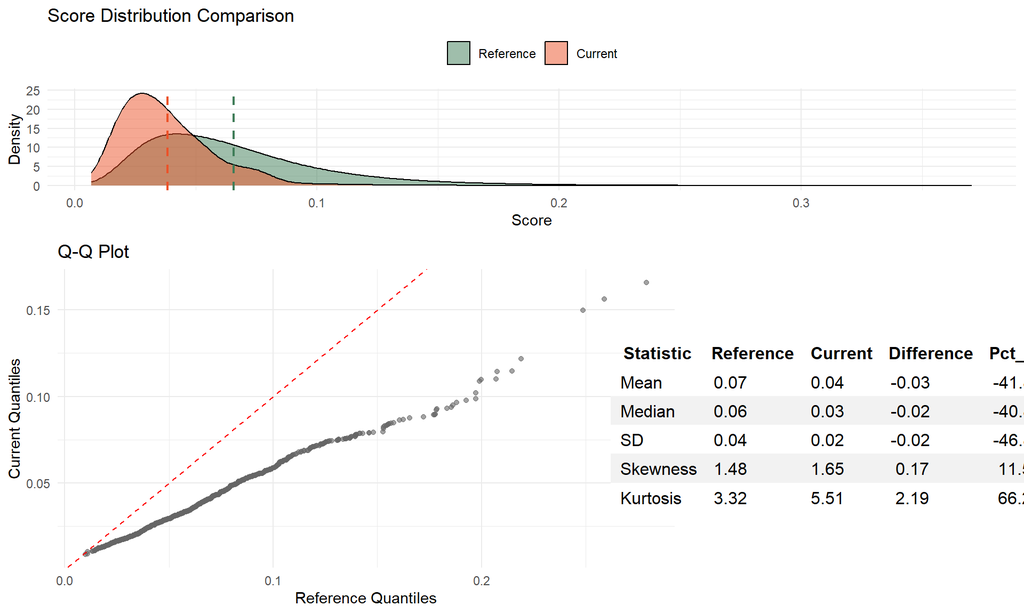

```r
# Calculate statistics
ref_stats <- c(
  Mean = mean(reference_predictions),
  Median = median(reference_predictions),
  SD = sd(reference_predictions),
  Skewness = skewness(reference_predictions),
  Kurtosis = kurtosis(reference_predictions)
)

curr_stats <- c(
  Mean = mean(current_predictions),
  Median = median(current_predictions),
  SD = sd(current_predictions),
  Skewness = skewness(current_predictions),
  Kurtosis = kurtosis(current_predictions)
)

# Create data frame for stats
stats_df <- data.frame(
  Statistic = names(ref_stats),
  Reference = round(ref_stats, 2),
  Current = round(curr_stats, 2),
  Difference = round(curr_stats - ref_stats, 2),
  Pct_Change = round((curr_stats - ref_stats) / ref_stats * 100, 1)
)

combined_df <- data.frame(
  Score = c(reference_predictions, current_predictions),
  Type = factor(
    c(
      rep("Reference", length(reference_predictions)),
      rep("Current", length(current_predictions))
    ),
    levels = c("Reference", "Current")
  )
)

# Store mean values for reference in the plot
ref_mean <- ref_stats["Mean"]
curr_mean <- curr_stats["Mean"]

# Create density plot
p1 <- ggplot(combined_df, aes(x = Score, fill = Type)) +
  geom_density(alpha = 0.5, adjust = 3) +
  scale_fill_manual(values = c("Current" = "#EC5228", "Reference" = "#3F7D58")) +
  geom_vline(xintercept = ref_mean, linetype = "dashed", color = "#3F7D58", size = 0.8) +
  geom_vline(xintercept = curr_mean, linetype = "dashed", color = "#EC5228", size = 0.8) +
  labs(
    title = "Score Distribution Comparison",
    x = "Score",
    y = "Density"
  ) +
  theme_minimal() +
  theme(legend.position = "top", legend.title = element_blank())

# Create a second plot for average scores

idx <- sample(1:min(length(current_predictions), length(reference_predictions)), size = 1000)

p2 <- ggplot(
  data.frame(
    x = sort(reference_predictions[idx]),
    y = sort(current_predictions[idx])
  ),
  aes(x = x, y = y)
) +
  geom_point(color = "#666666", alpha = 0.6) +
  geom_abline(intercept = 0, slope = 1, color = "red", linetype = "dashed") +
  labs(
    title = "Q-Q Plot",
    x = "Reference Quantiles",
    y = "Current Quantiles"
  ) +
  theme_minimal()

# Create table for stats
p3 <- tableGrob(stats_df, rows = NULL, theme = ttheme_minimal(
  core = list(
    fg_params = list(hjust = 0, x = 0.1),
    bg_params = list(fill = c("white", "grey95"))
  ),
  colhead = list(fg_params = list(fontface = "bold"))
))

# Arrange plots
grid.arrange(p1, p2, p3,
             layout_matrix = rbind(c(1, 1, 1), c(2, 2, 3), c(2, 2, 3)),
             heights = c(1, 0.8, 0.8)
)
```

## Discrimination - Overall

The discrimination metrics below provide a comprehensive assessment of the model’s ability to differentiate between good and bad outcomes. Each metric offers a unique perspective on model performance:

1. **AUC (Area Under the ROC Curve)**: Measures the model’s ability to rank order risk correctly. An AUC of 0.5 indicates random predictions, while 1.0 represents perfect discrimination.
2. **Gini Coefficient**: A transformation of AUC (Gini = 2*AUC-1) that ranges from 0 to 1, with higher values indicating better discrimination power. The Gini coefficient is widely used in credit scoring to assess model quality, with values above 0.4 generally considered good for credit risk models.
3. **KS (Kolmogorov-Smirnov) Statistic**: Measures the maximum separation between the cumulative distribution functions of scores for good and bad accounts. Higher values indicate better separation between the two populations, with the theoretical maximum being 1.0.

These metrics should be monitored for stability over time. Any significant decrease could indicate model degradation or population drift requiring further investigation.

**Note that significant change in Gini/IV due to low population size should be ignored**

```r
# First, create a table showing thresholds for interpreting feature metrics
metrics_guide <- data.frame(
  Metric = c("Information Value (IV)", "Correlation", "KS Statistic", "Gini Coefficient"),
  Poor = c("<0.02", "<0.1", "<0.1", "<0.2"),
  Fair = c("0.02-0.1", "0.1-0.2", "0.1-0.2", "0.2-0.4"),
  Good = c("0.1-0.3", "0.2-0.4", "0.2-0.3", "0.4-0.6"),
  Excellent = c(">0.3", ">0.4", ">0.3", ">0.6")
)

# Display the metrics guide table
datatable(metrics_guide,
          options = list(
            dom = "t",
            ordering = FALSE
          ),
          rownames = FALSE
) %>%
  formatStyle(
    "Poor",
    backgroundColor = "#f8d7da",
    fontWeight = "bold"
  ) %>%
  formatStyle(
    "Fair",
    backgroundColor = "#fff3cd",
    fontWeight = "bold"
  ) %>%
  formatStyle(
    "Good",
    backgroundColor = "#c3e6cb",
    fontWeight = "bold"
  ) %>%
  formatStyle(
    "Excellent",
    backgroundColor = "#d4edda",
    fontWeight = "bold"
  )
```

| Metric | Poor | Fair | Good | Excellent |
| --- | --- | --- | --- | --- |
| Information Value (IV) | &lt;0.02 | 0.02-0.1 | 0.1-0.3 | &gt;0.3 |
| Correlation | &lt;0.1 | 0.1-0.2 | 0.2-0.4 | &gt;0.4 |
| KS Statistic | &lt;0.1 | 0.1-0.2 | 0.2-0.3 | &gt;0.3 |
| Gini Coefficient | &lt;0.2 | 0.2-0.4 | 0.4-0.6 | &gt;0.6 |

```r
# Calculate ROC curve
roc_obj <- roc(current_target, current_predictions)
auc_value <- round(auc(roc_obj), 3)
gini_value <- 2 * auc_value - 1

roc_obj <- roc(reference_target, reference_predictions)
auc_value_ref <- round(auc(roc_obj), 3)
gini_value_ref <- 2 * auc_value_ref - 1

# Calculate KS statistic
pred <- prediction(current_predictions, current_target)
perf <- performance(pred, "tpr", "fpr")
ks_value <- max(abs(unlist(perf@y.values) - unlist(perf@x.values)))

pred <- prediction(reference_predictions, reference_target)
perf <- performance(pred, "tpr", "fpr")
ks_value_ref <- max(abs(unlist(perf@y.values) - unlist(perf@x.values)))

# Create metrics table with assessment
metrics_table <- data.frame(
  Metric = c("AUC", "Gini", "KS Statistic"),
  Value_Current = c(auc_value, gini_value, ks_value),
  Assessment = c(
    case_when(
      auc_value >= 0.8 ~ "Excellent",
      auc_value >= 0.7 ~ "Good",
      auc_value >= 0.6 ~ "Fair",
      TRUE ~ "Poor"
    ),
    case_when(
      gini_value >= 0.6 ~ "Excellent",
      gini_value >= 0.4 ~ "Good",
      gini_value >= 0.2 ~ "Fair",
      TRUE ~ "Poor"
    ),
    case_when(
      ks_value >= 0.5 ~ "Excellent",
      ks_value >= 0.3 ~ "Good",
      ks_value >= 0.2 ~ "Fair",
      TRUE ~ "Poor"
    )
  ),
  Value_Reference = c(auc_value_ref, gini_value_ref, ks_value_ref)
)

datatable(metrics_table, options = list(dom = "t")) %>%
  formatRound("Value_Current", 3) %>%
  formatRound("Value_Reference", 3) %>%
  formatStyle(
    "Assessment",
    backgroundColor = styleEqual(
      c("Excellent", "Good", "Fair", "Poor"),
      c("#d4edda", "#c3e6cb", "#fff3cd", "#f8d7da")
    ),
    fontWeight = "bold"
  )
```

|  | Metric | Value_Current | Assessment | Value_Reference |
| --- | --- | --- | --- | --- |
| 1 | AUC | 0.62 | Fair | 0.665 |
| 2 | Gini | 0.24 | Fair | 0.3300000000000001 |
| 3 | KS Statistic | 0.1866313780449657 | Poor | 0.2372510909979649 |

### Discrimination - By Bureau Groups

```r
gini_result <- calculate_gini(
  data = current_data,
  score_col = "predicted",
  target_col = "target",
  date_col = "SourceMonth",
  group_col = "bureau_buckets"
)

print.gini_analysis(gini_result)
```

| Group | Period | Reference Period | Gini | Event Rate | Population % | Gini Change % | Status |
| --- | --- | --- | --- | --- | --- | --- | --- |
| 650-700 | 2025M3 | 2025M2 | 0.1616752268293993 | 0.04914322664080181 | 0.06365769325759446 | -0.7062301248796174 | Investigate |
| 700-750 | 2025M3 | 2025M2 | 0.1904081034237488 | 0.04362384894428425 | 0.2212686259981889 | -0.1785116380958421 | Investigate |
| &lt;=650 | 2025M3 | 2025M2 | 0.6139999999999999 | 0.0310077519379845 | 0.002654976537416646 | 5.689368421052633 | Investigate |
| &gt;750 | 2025M3 | 2025M2 | 0.2660516330838096 | 0.0475448168355417 | 0.3168683625586565 | 0.02884815759641355 | Stable |
| NTC | 2025M3 | 2025M2 | 0.2122958693563881 | 0.02528089887640449 | 0.007326911994731209 | -0.1159526847915803 | Investigate |

### Discrimination - By Risk Segments

```r
gini_result <- calculate_gini(
  data = current_data,
  score_col = "predicted",
  target_col = "target",
  date_col = "SourceMonth",
  group_col = "lrvs_risk_segment"
)

print(gini_result)
```

| Group | Period | Reference Period | Gini | Event Rate | Population % | Gini Change % | Status |
| --- | --- | --- | --- | --- | --- | --- | --- |
| REPEAT | 2025M3 | 2025M2 | 0.2313484772426573 | 0.04749757045675413 | 0.5082736478142751 | -0.1016138154723554 | Investigate |
| TOPUP | 2025M3 | 2025M2 | 0.187851690902 | 0.03837741101610658 | 0.1035029225323125 | -0.2756986020351674 | Investigate |

### Discrimination - By Pincode Color

```r
gini_result <- calculate_gini(
  data = current_data,
  score_col = "predicted",
  target_col = "target",
  date_col = "SourceMonth",
  group_col = "lrv_pincodeColor"
)

print(gini_result)
```

| Group | Period | Reference Period | Gini | Event Rate | Population % | Gini Change % | Status |
| --- | --- | --- | --- | --- | --- | --- | --- |
| DARK_GREEN | 2025M3 | 2025M2 | 0.1735667001527643 | 0.05824255628177197 | 0.1417016547295629 | -0.1246089595016066 | Investigate |
| GREEN | 2025M3 | 2025M2 | 0.1887577488897114 | 0.05109875562615833 | 0.0777352432699432 | -0.08849243604213194 | Monitor |
| LIGHT_GREEN | 2025M3 | 2025M2 | 0.2270460962332612 | 0.05334595959595959 | 0.06520128426772043 | -0.301908579232139 | Investigate |
| YELLOW | 2025M3 | 2025M2 | 0.2392270706802546 | 0.03793645800566216 | 0.3271383880793612 | -0.1190211280755251 | Investigate |

### Discrimination - By Vintage Groups

```r
gini_result <- calculate_gini(
  data = current_data,
  score_col = "predicted",
  target_col = "target",
  date_col = "SourceMonth",
  group_col = "vintage_buckets"
)

print(gini_result)
```

| Group | Period | Reference Period | Gini | Event Rate | Population % | Gini Change % | Status |
| --- | --- | --- | --- | --- | --- | --- | --- |
| &lt;=150Days | 2025M3 | 2025M2 | 0.2272300469483568 | 0.04484304932735426 | 0.004590649896041336 | 1.570387197738405 | Investigate |
| &lt;=30Days | 2025M3 | 2025M2 | 0.5695792880258901 | 0.02830188679245283 | 0.004364205282335261 | 1.490468141975553 | Investigate |
| &gt;150Days | 2025M3 | 2025M2 | 0.2299980240901864 | 0.04610813210833703 | 0.6027338040636515 | -0.1141831183421296 | Investigate |

# Risk Ranking Analysis

Risk ranking analysis evaluates how well the model separates good and bad accounts across the score distribution. This analysis is critical for assessing model discrimination power and for making informed cutoff decisions.

## Risk Decile Analysis

The following visualizations compare the model’s performance across score deciles between the current and reference periods. These charts help identify shifts in risk distribution and model effectiveness.

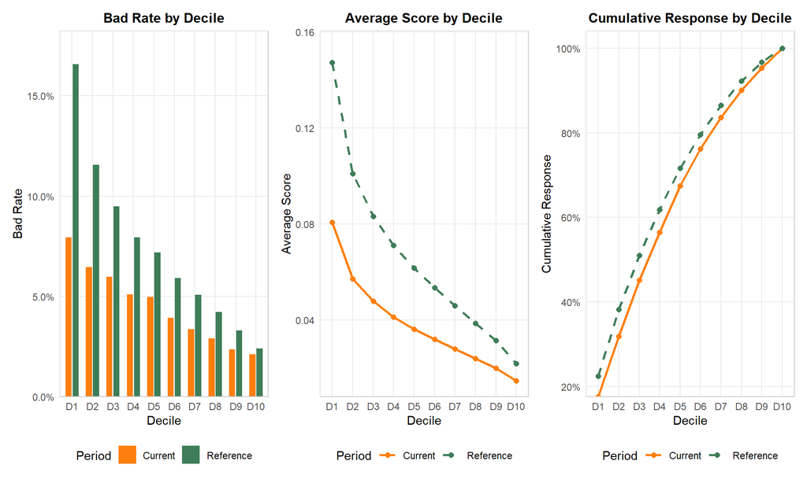

```r
# Calculate risk metrics
risk_metrics <- create_risk_ranking_plot()

# Define a consistent color palette for all charts
current_color <- "#ff7f0e" # Green for current
reference_color <- "#3F7D58" # Orange for reference

# Base plot for bad rates
p1 <- ggplot(risk_metrics, aes(x = decile, group = period)) +
  geom_bar(
    aes(y = bad_rate, fill = period),
    stat = "identity",
    position = position_dodge(width = 0.7),
    width = 0.6
  ) +
  scale_fill_manual(
    values = c("Current" = current_color, "Reference" = reference_color),
    name = "Period"
  ) +
  # Format y-axis as percentage
  scale_y_continuous(
    labels = scales::percent_format(accuracy = 0.1),
    expand = expansion(mult = c(0, 0.1))
  ) +
  labs(
    title = "Bad Rate by Decile",
    x = "Decile",
    y = "Bad Rate"
  ) +
  theme_minimal() +
  theme(
    legend.position = "none",
    plot.title = element_text(hjust = 0.5, face = "bold", size = 12),
    axis.text.x = element_text(angle = 0, hjust = 0.5),
    panel.grid.minor = element_blank(),
    panel.border = element_rect(color = "grey80", fill = NA, size = 0.5)
  )

# Create a second plot for average scores
p2 <- ggplot(risk_metrics, aes(x = decile, group = period)) +
  geom_line(
    aes(y = avg_score, color = period, linetype = period),
    size = 1
  ) +
  geom_point(
    aes(y = avg_score, color = period),
    size = 2
  ) +
  scale_color_manual(
    values = c("Current" = current_color, "Reference" = reference_color),
    name = "Period"
  ) +
  scale_linetype_manual(
    values = c("Current" = "solid", "Reference" = "dashed"),
    name = "Period"
  ) +
  # Format y-axis with appropriate decimal places
  scale_y_continuous(
    labels = scales::number_format(accuracy = 0.01),
    expand = expansion(mult = c(0.05, 0.1))
  ) +
  labs(
    title = "Average Score by Decile",
    x = "Decile",
    y = "Average Score"
  ) +
  theme_minimal() +
  theme(
    legend.position = "none",
    plot.title = element_text(hjust = 0.5, face = "bold", size = 12),
    panel.grid.minor = element_blank(),
    panel.border = element_rect(color = "grey80", fill = NA, size = 0.5)
  )

# Create a third plot for cumulative response
p3 <- ggplot(risk_metrics, aes(x = decile, group = period)) +
  geom_line(
    aes(y = captured_response, color = period, linetype = period),
    size = 1
  ) +
  geom_point(
    aes(y = captured_response, color = period),
    size = 2
  ) +
  scale_color_manual(
    values = c("Current" = current_color, "Reference" = reference_color),
    name = "Period"
  ) +
  scale_linetype_manual(
    values = c("Current" = "solid", "Reference" = "dashed"),
    name = "Period"
  ) +
  # Format y-axis as percentage
  scale_y_continuous(
    labels = scales::percent_format(accuracy = 1),
    expand = expansion(mult = c(0, 0.05))
  ) +
  labs(
    title = "Cumulative Response by Decile",
    x = "Decile",
    y = "Cumulative Response"
  ) +
  theme_minimal() +
  theme(
    legend.position = "none",
    plot.title = element_text(hjust = 0.5, face = "bold", size = 12),
    panel.grid.minor = element_blank(),
    panel.border = element_rect(color = "grey80", fill = NA, size = 0.5)
  )

p1 + p2 + p3 + plot_layout(guides = "keep") & theme(legend.position = "bottom")
```

### Interpretation of Risk Decile Charts

The risk decile analysis provides three key perspectives on model performance:

1. **Bad Rate by Decile**:
- Shows the percentage of bad accounts within each score decile
- A well-performing model should demonstrate a clear monotonic trend with higher bad rates in lower deciles
- Significant changes in bad rates between periods, especially in certain deciles, may indicate population shifts or model degradation
- Pay special attention to deciles near your approval threshold, as changes here directly impact portfolio performance
2. **Average Score by Decile**:
- Illustrates the average model score within each decile
- Helps identify score compression or expansion across the distribution
- Parallel lines between periods suggest consistent relative scoring, while converging or diverging lines may indicate score recalibration needs
- Large gaps between current and reference lines may require score normalization for consistent decision-making
3. **Cumulative Response by Decile**:
- Displays the cumulative percentage of bad accounts captured up to each decile
- The steeper the curve in lower deciles, the better the model’s ability to identify bad accounts
- Divergence between current and reference curves indicates changes in the model’s discriminatory power
- Ideally, the model should capture a high percentage of bad accounts in the lowest deciles

### Key Metrics to Monitor

When reviewing these charts, focus on:

- **Monotonicity**: Bad rates should consistently decrease as deciles increase
- **Separation**: Clear separation between deciles indicates good discriminatory power
- **Stability**: Similar patterns between current and reference periods suggest model stability
- **Concentration**: High concentration of bad accounts in lower deciles indicates effective risk ranking

Changes in these patterns may warrant further investigation into specific population segments or model recalibration.

## Calibration Analysis

Calibration assesses how well predicted probabilities align with actual outcomes. A well-calibrated model should produce probability estimates that match the observed frequency of events.

The Brier score is a quantitative measure of calibration quality. Lower scores indicate better calibration:

```r
# Create data frame for Brier score interpretation guide
brier_guide <- data.frame(
  Brier_Score_Range = c("0.00 - 0.10", "0.10 - 0.20", "0.20 - 0.30", "0.30 - 0.40", "> 0.40"),
  Interpretation = c("Excellent", "Good", "Acceptable", "Poor", "Very Poor"),
  Description = c(
    "Exceptional calibration, predictions closely match actual outcomes",
    "Strong calibration, reliable for decision-making",
    "Reasonable calibration, but some room for improvement",
    "Significant calibration issues, use with caution",
    "Major calibration problems, model may need recalibration"
  ),
  Status = c("Excellent", "Good", "Acceptable", "Poor", "Very Poor")
)

# Create formatted datatable
datatable(brier_guide,
          options = list(
            dom = "t", # Show only the table (no search, pagination)
            ordering = FALSE, # Disable ordering
            columnDefs = list(list(targets = 3, visible = FALSE)) # Hide Status column
          ),
          rownames = FALSE
) %>%
  formatStyle(
    columns = c("Brier_Score_Range", "Interpretation", "Description"),
    valueColumns = "Status",
    backgroundColor = styleEqual(
      c("Excellent", "Good", "Acceptable", "Poor", "Very Poor"),
      c("#d4edda", "#c3e6cb", "#fff3cd", "#f8d7da", "#dc3545")
    ),
    fontWeight = "bold"
  )
```

| Brier_Score_Range | Interpretation | Description | Status |
| --- | --- | --- | --- |
| 0.00 - 0.10 | Excellent | Exceptional calibration, predictions closely match actual outcomes | Excellent |
| 0.10 - 0.20 | Good | Strong calibration, reliable for decision-making | Good |
| 0.20 - 0.30 | Acceptable | Reasonable calibration, but some room for improvement | Acceptable |
| 0.30 - 0.40 | Poor | Significant calibration issues, use with caution | Poor |
| &gt; 0.40 | Very Poor | Major calibration problems, model may need recalibration | Very Poor |

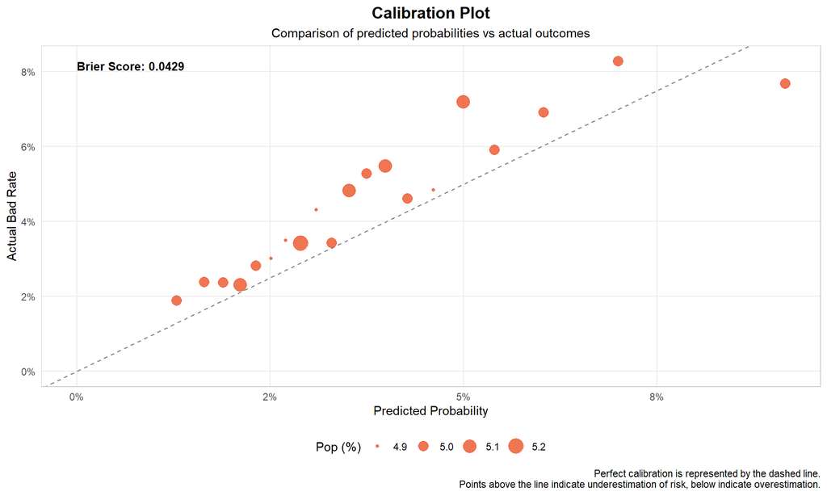

```r
calibration_plot <- create_calibration_plot()
calibration_plot
```

# Feature Analysis

## Performance Metrics

**Note** that if a variable could not be discretised, IV will not populate.

```r
# Calculate metrics for current and reference datasets
current_metrics <- calculate_performance_metrics(current_data, current_target, features_to_analyze)
reference_metrics <- calculate_performance_metrics(reference_data, reference_target, features_to_analyze)

# Calculate absolute and percentage changes
performance_comparison <- current_metrics %>%
  rename(
    Current_IV = IV,
    Current_Correlation = Correlation,
    Current_KS = KS_Statistic
    # Current_Gini = Gini
  ) %>%
  left_join(
    reference_metrics %>%
      rename(
        Reference_IV = IV,
        Reference_Correlation = Correlation,
        Reference_KS = KS_Statistic
        # Reference_Gini = Gini
      ),
    by = "Feature"
  ) %>%
  mutate(
    IV_Change = Current_IV - Reference_IV,
    IV_Pct_Change = (Current_IV - Reference_IV) / Reference_IV * 100,
    Correlation_Change = Current_Correlation - Reference_Correlation,
    KS_Change = Current_KS - Reference_KS
    # Gini_Change = Current_Gini - Reference_Gini,
    # Gini_Pct_Change = (Current_Gini - Reference_Gini) / Reference_Gini * 100
  )
  # arrange(Gini_Pct_Change)

# Display the comparison with highlighting
datatable(
  performance_comparison %>%
    select(
      Feature,
      Current_IV, Reference_IV, IV_Pct_Change,
      Current_Correlation, Reference_Correlation, Correlation_Change
    ),
  options = list(
    pageLength = 10,
    buttons = c("copy", "csv", "excel")
  ),
  rownames = FALSE
) %>%
  formatRound(columns = 2:7, digits = 3) %>%
  # Highlight Correlation changes
  formatStyle(
    "Correlation_Change",
    background = styleInterval(
      c(-0.2, -0.1, 0.1, 0.2),
      c("#f8d7da", "#fff3cd", "white", "#fff3cd", "#f8d7da")
    )
  ) %>%
  # Highlight Gini changes
  formatStyle(
    "IV_Pct_Change",
    background = styleInterval(
      c(-0.2, -0.1, 0.1, 0.2),
      c("#f8d7da", "#fff3cd", "white", "#fff3cd", "#f8d7da")
    )
  )
```

| Feature | Current_IV | Reference_IV | IV_Pct_Change | Current_Correlation | Reference_Correlation | Correlation_Change |
| --- | --- | --- | --- | --- | --- | --- |
| speaker_vintage | 0.003428411717488176 | 0.05219261971904508 | -93.4312327376103 | -0.01117385421057701 | 0.06030220696379491 | -0.07147606117437193 |
| total_active_vintage | 0.04396498541506805 | 0.04769273245394711 | -7.816174178065048 | -0.03434950164937631 | -0.05340573807658088 | 0.01905623642720457 |
| active_days_ratio_working_hour | 0.003652935950052516 | 0.0002872604064462881 | 1171.646167755298 | -0.06377683390753945 | -0.05734621856760369 | -0.006430615339935761 |
| rsd_txn | 0.004810323797935978 | 0.0002556163028175534 | 1781.853287491352 | 0.03915150923229292 | 0.06125554469393419 | -0.02210403546164127 |
| txn_per_active_day_non_working_hour | 0.000375168468963026 | 0.009125329666070025 | -95.88871325539081 | 0.001011977138382414 | 0.04457753763571103 | -0.04356556049732861 |
| dist_diff_metres_onboarding_lending_geohash | 0 | 0.007099855487919815 | -100 |  | 0.04410594546472312 |  |
| active_days_ratio_0_30_qr | 0.0001815463874907595 | 0.0004087200285959226 | -55.58172470421222 | -0.05512113405617083 | -0.05106321298370015 | -0.004057921072470681 |
| vintage | 0.02690980611803861 | 0.03020830112120591 | -10.91916751601692 | -0.03047305361075363 | -0.04504271574833596 | 0.01456966213758233 |
| active_days_ratio_0_30_working_hour | 0.001110849290277604 | 0.0003734805927270474 | 197.431596690608 | -0.05494322805623428 | -0.05386823095630926 | -0.001074997099925021 |
| rsd_sum_tpv | 0.004810323797935978 | 0.0002556163028175534 | 1781.853287491352 | 0.0288185748563728 | 0.05088129199252228 | -0.02206271713614948 |

[output cut: 11 more lines]

## Stability Analysis

### PSI Values

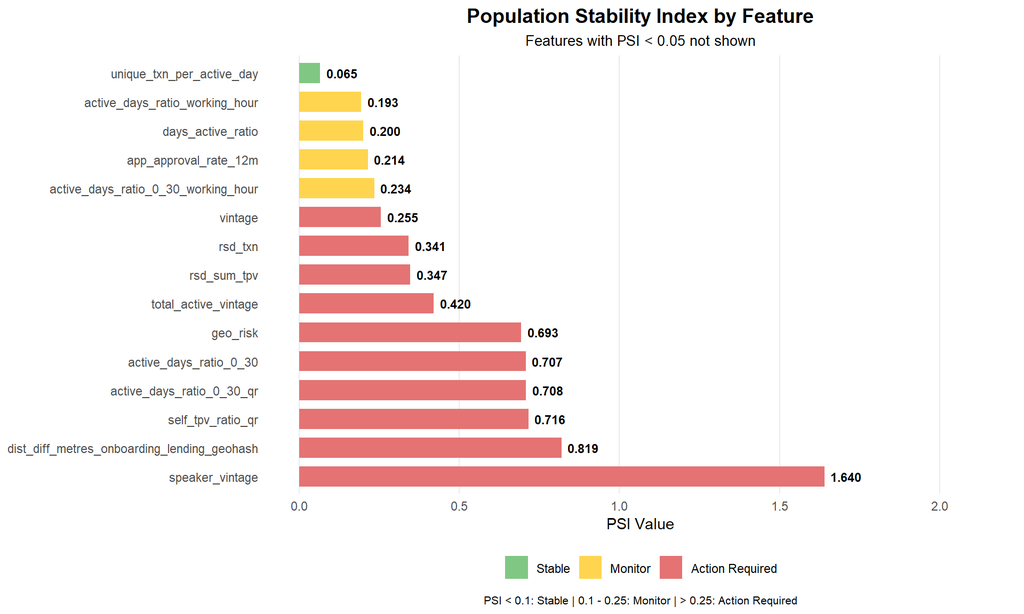

```r
# Calculate PSI for each feature
psi_values <- data.frame(
  Feature = features_to_analyze,
  PSI = sapply(features_to_analyze, calculate_psi)
)

# Add categorization based on PSI thresholds and sort by PSI value
psi_values <- psi_values %>%
  mutate(
    PSI_Category = case_when(
      PSI < 0.1 ~ "Stable",
      PSI < 0.25 ~ "Monitor",
      TRUE ~ "Action Required"
    ),
    # Reorder factors for proper legend ordering
    PSI_Category = factor(PSI_Category, levels = c("Stable", "Monitor", "Action Required"))
  ) %>%
  # Sort by PSI value descending
  arrange(desc(PSI))

# Create a new column for ordered feature names
psi_values$Feature_Ordered <- factor(psi_values$Feature,
                                     levels = psi_values$Feature[order(psi_values$PSI, decreasing = TRUE)]
)


psi_values %>%
  filter(PSI >= 0.05) %>%
  # Create a better visualization with ggplot2
  ggplot(aes(
    x = PSI,
    y = Feature_Ordered,
    fill = PSI_Category
  )) +

  # Add horizontal bars
  geom_bar(stat = "identity", width = 0.7) +

  # Add PSI values as text on the bars
  geom_text(aes(label = sprintf("%.3f", PSI)),
            hjust = -0.2,
            size = 3,
            fontface = "bold"
  ) +

  # Set colors based on PSI categories
  scale_fill_manual(values = c(
    "Stable" = "#81C784", # Green for stable
    "Monitor" = "#FFD54F", # Yellow for monitor
    "Action Required" = "#E57373" # Red for action required
  )) +

  # Set x-axis limits to accommodate text labels
  scale_x_continuous(limits = c(0, max(psi_values$PSI) * 1.3)) +

  # Add labels and title
  labs(
    title = "Population Stability Index by Feature",
    subtitle = "Features with PSI < 0.05 not shown",
    x = "PSI Value",
    y = NULL,
    caption = "PSI < 0.1: Stable | 0.1 - 0.25: Monitor | > 0.25: Action Required"
  ) +

  # Customize theme
  theme_minimal() +
  theme(
    plot.title = element_text(face = "bold", size = 14, hjust = 0.5),
    plot.subtitle = element_text(size = 10, hjust = 0.5),
    legend.position = "bottom",
    legend.title = element_blank(),
    panel.grid.major.y = element_blank(),
    panel.grid.minor = element_blank(),
    plot.caption = element_text(hjust = 0.5, size = 8)
  )
```

```r
psi_values %>%
  mutate(PSI = round(PSI, 3)) %>%
  select(Feature, PSI, PSI_Category) %>%
  datatable() %>%

  formatStyle(
    'PSI_Category',
    backgroundColor = styleEqual(
      c("Stable", "Monitor", "Action Required"),
      c('#d4edda', '#fff3cd', '#f8d7da')
    ),
    fontWeight = 'bold'
  )
```

|  | Feature | PSI | PSI_Category |
| --- | --- | --- | --- |
| speaker_vintage | speaker_vintage | 1.64 | Action Required |
| dist_diff_metres_onboarding_lending_geohash | dist_diff_metres_onboarding_lending_geohash | 0.819 | Action Required |
| self_tpv_ratio_qr | self_tpv_ratio_qr | 0.716 | Action Required |
| active_days_ratio_0_30_qr | active_days_ratio_0_30_qr | 0.708 | Action Required |
| active_days_ratio_0_30 | active_days_ratio_0_30 | 0.707 | Action Required |
| geo_risk | geo_risk | 0.693 | Action Required |
| total_active_vintage | total_active_vintage | 0.42 | Action Required |
| rsd_sum_tpv | rsd_sum_tpv | 0.347 | Action Required |
| rsd_txn | rsd_txn | 0.341 | Action Required |
| vintage | vintage | 0.255 | Action Required |

[output cut: 11 more lines]

### Distribution Analysis

```r
nms <- psi_values %>%
  arrange(desc(PSI)) %>%
  pull(Feature)

for (feature_name in nms) {
  results <- analyze_psi_bins(
    current_data = current_data,
    reference_data = reference_data,
    score_col = feature_name,
    bins = 10, # number of bins
    psi_threshold = 0.1, # threshold for overall PSI
    bin_psi_threshold = 0.02 # threshold for bin-level shifts
  )

  # Create visualizations
  cat(feature_name)
  plot_psi_analysis(results, feature_name)
}
```

speaker_vintage

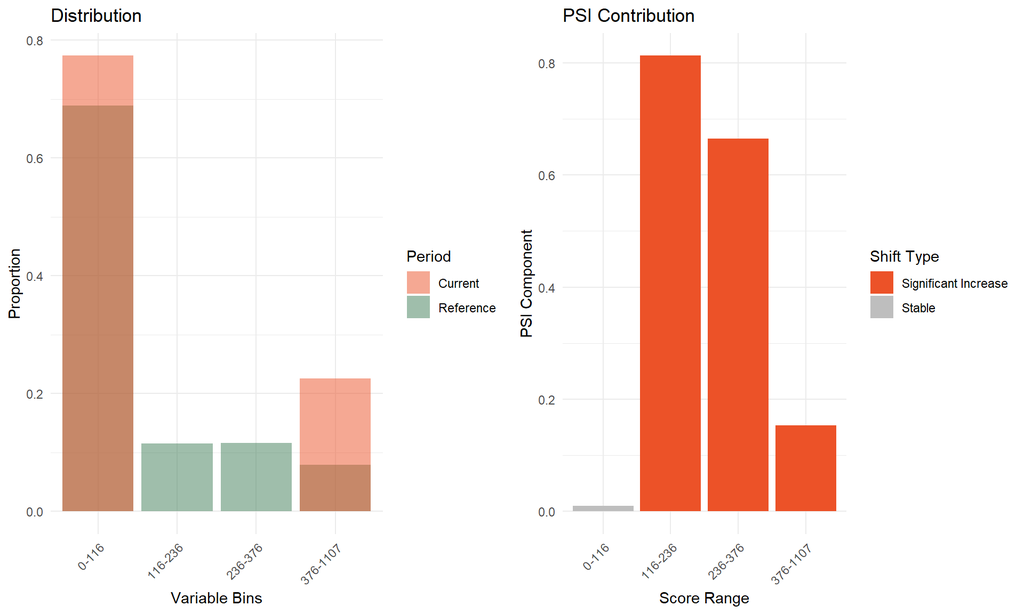

dist_diff_metres_onboarding_lending_geohash

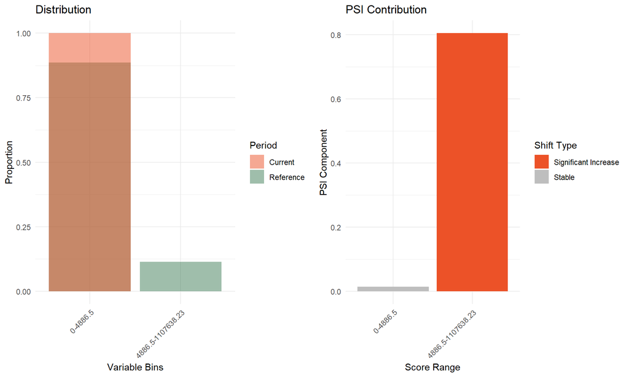

self_tpv_ratio_qr

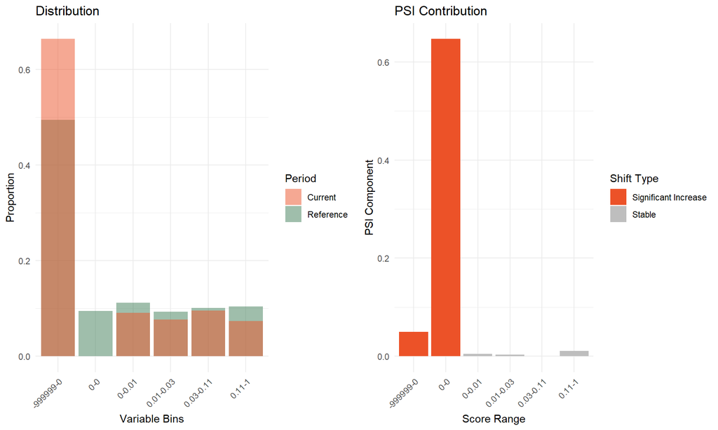

active_days_ratio_0_30_qr

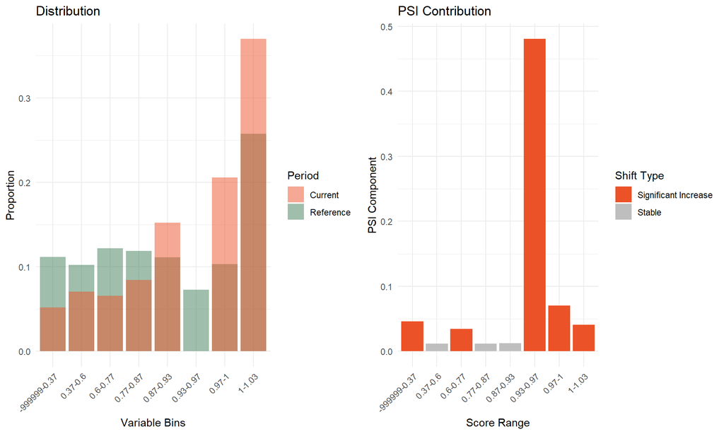

active_days_ratio_0_30

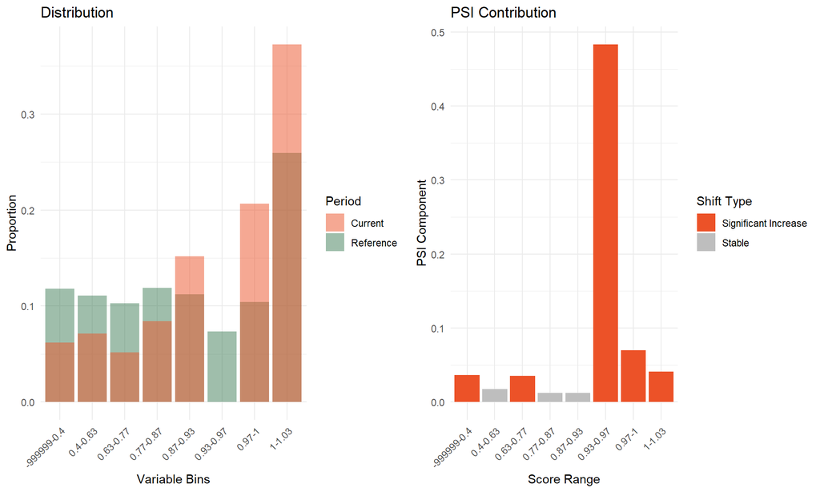

geo_risk

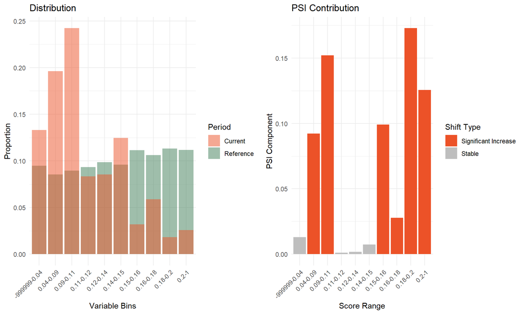

total_active_vintage

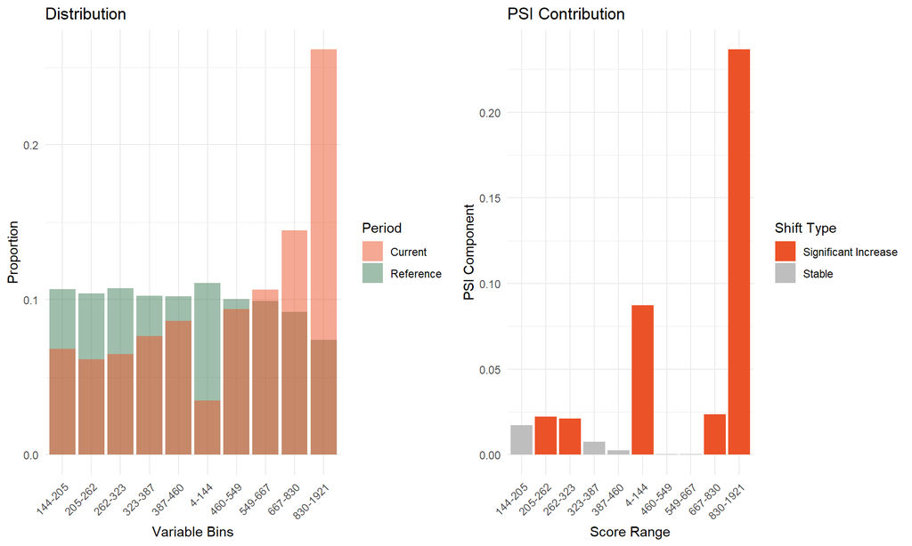

rsd_sum_tpv

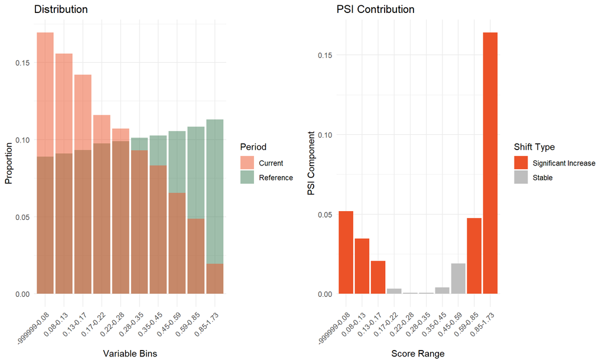

rsd_txn

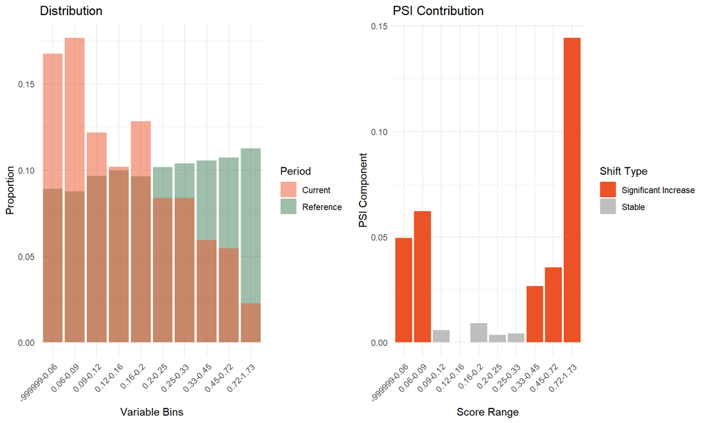

vintage

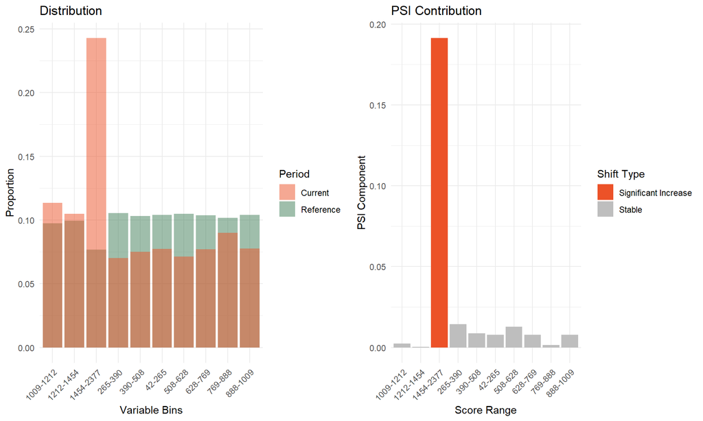

active_days_ratio_0_30_working_hour

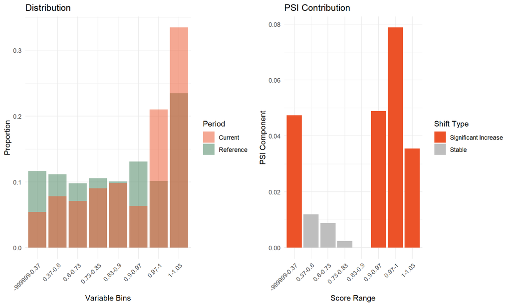

app_approval_rate_12m

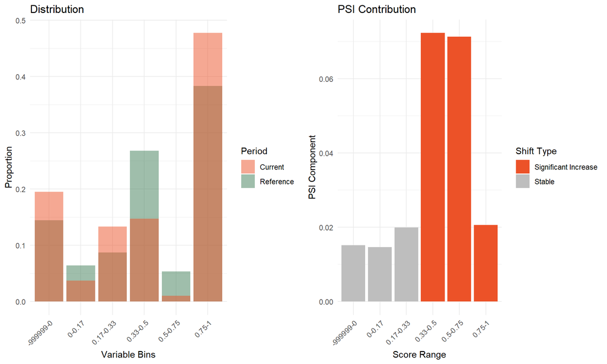

days_active_ratio

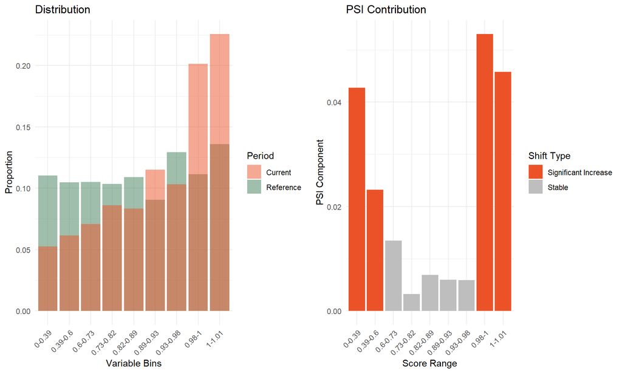

active_days_ratio_working_hour

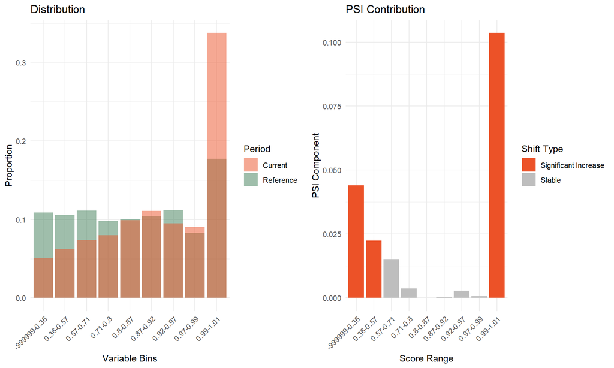

unique_txn_per_active_day

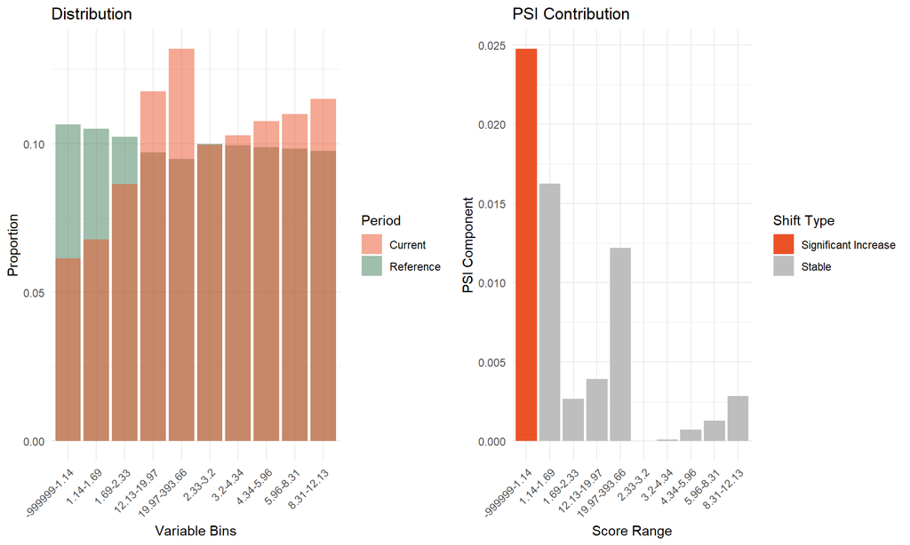

shift_txn_m1_m3

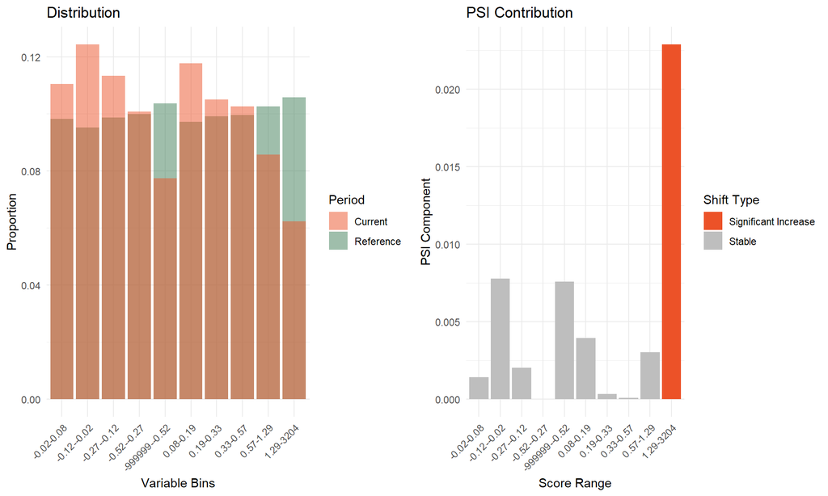

shift_txn_m1_m2

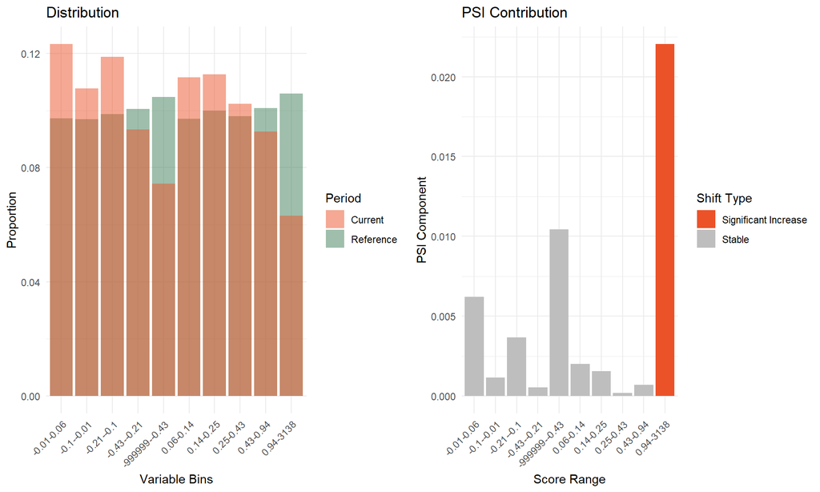

avg_ticket_value_qr

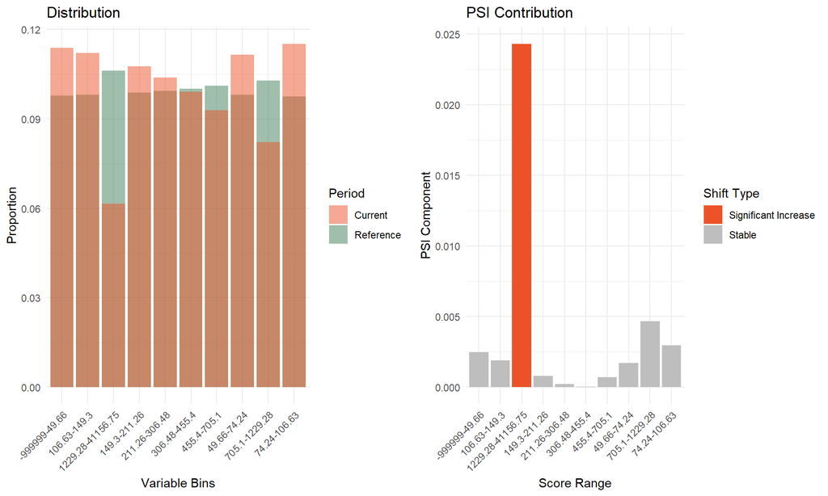

total_applications

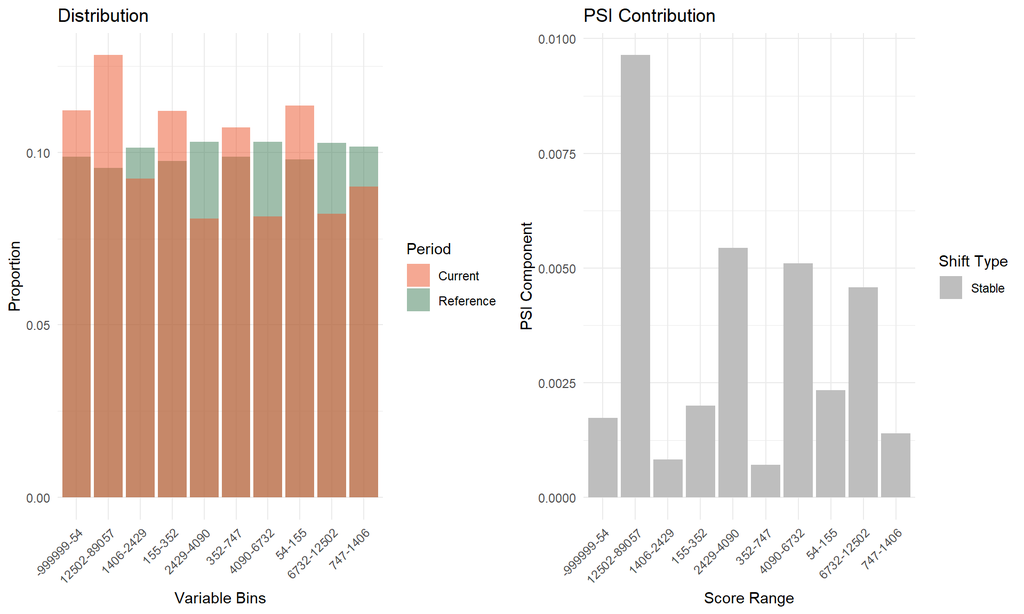

avg_ticket_value_30_60_qr

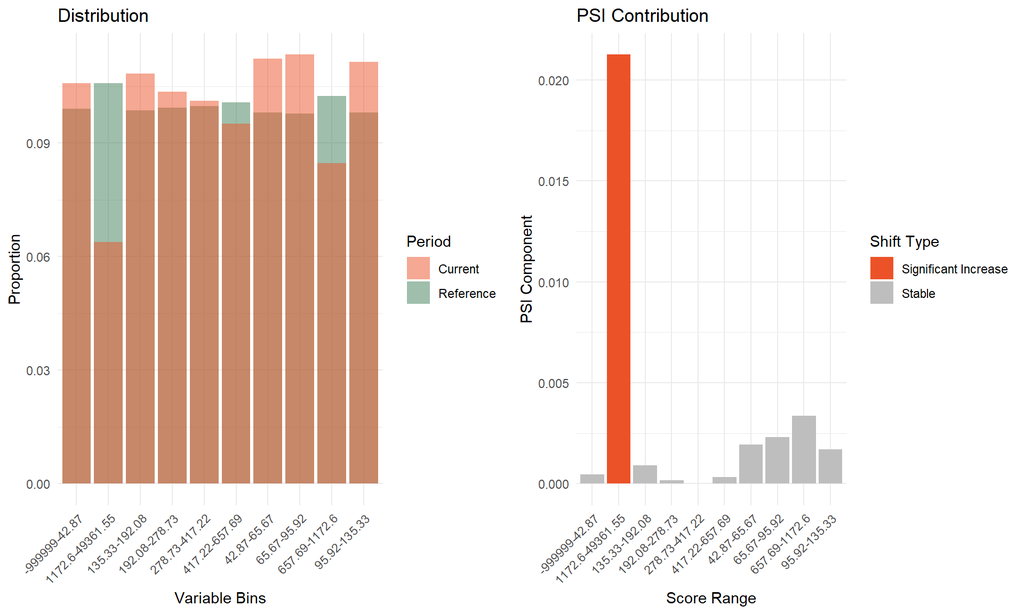

txn_per_active_day_non_working_hour

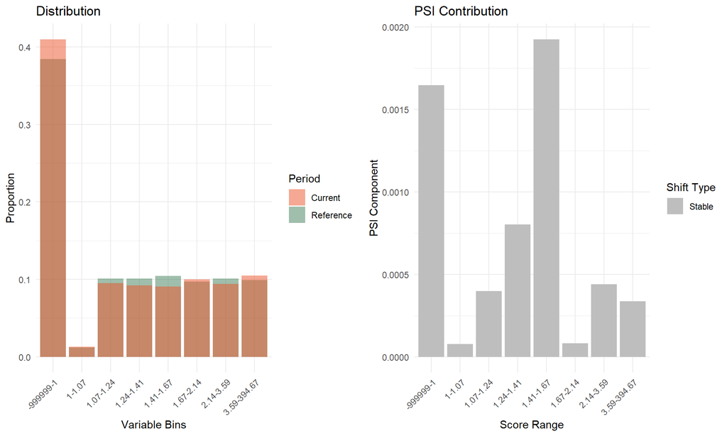

### Summary Statistics

```r
# Calculate summary statistics for each feature and period

curr_df <- current_data
curr_df[curr_df < 0] <- NA

ref_df <- reference_data
ref_df[ref_df < 0] <- NA

summary_stats <- rbind(

  # Current period stats
  data.frame(
    Feature = features_to_analyze,
    Period = "Current",
    Mean = sapply(curr_df[, ..features_to_analyze], mean, na.rm = T),
    SD = sapply(curr_df[, ..features_to_analyze], sd, na.rm = T),
    Q1 = sapply(curr_df[, ..features_to_analyze], quantile, probs = 0.25, na.rm = T),
    Median = sapply(curr_df[, ..features_to_analyze], median, na.rm = T),
    Q3 = sapply(curr_df[, ..features_to_analyze], quantile, probs = 0.75, na.rm = T)
  ),

  # Reference period stats
  data.frame(
    Feature = features_to_analyze,
    Period = "Reference",
    Mean = sapply(ref_df[, ..features_to_analyze], mean, na.rm = T),
    SD = sapply(ref_df[, ..features_to_analyze], sd, na.rm = T),
    Q1 = sapply(ref_df[, ..features_to_analyze], quantile, probs = 0.25, na.rm = T),
    Median = sapply(ref_df[, ..features_to_analyze], median, na.rm = T),
    Q3 = sapply(ref_df[, ..features_to_analyze], quantile, probs = 0.75, na.rm = T)
  )
)

# Order by Feature and Period to group features together
summary_stats <- summary_stats[order(summary_stats$Feature, summary_stats$Period), ]

# Add group indicator for alternating colors
summary_stats$Group <- rep(rep(c(1, 2), length.out = length(unique(summary_stats$Feature))), each = 2)

datatable(
  summary_stats,
  rownames = FALSE,
  options = list(
    pageLength = 10, # Show all rows
    ordering = FALSE, # Disable sorting to maintain grouping
    columnDefs = list(list(targets = 7, visible = FALSE)) # Hide Status column
  )
) %>%
  formatRound(columns = 3:7, digits = 3) %>%
  formatStyle(
    "Feature",
    valueColumns = "Group",
    backgroundColor = styleEqual(c(1, 2), c("#ffffff", "#f9f9f9"))
  ) %>%
  formatStyle(
    "Period",
    backgroundColor = styleEqual(
      c("Current", "Reference"),
      c("#f2f2f2", "#ffffff")
    )
  )
```

| Feature | Period | Mean | SD | Q1 | Median | Q3 | Group |
| --- | --- | --- | --- | --- | --- | --- | --- |
| active_days_ratio_0_30 | Current | 0.8831445296397065 | 0.2181046531153501 | 0.83 | 0.97 | 1.03 | 1 |
| active_days_ratio_0_30 | Reference | 0.8179734583512691 | 0.2535304366532363 | 0.7 | 0.933333333333333 | 1.03333333333333 | 1 |
| active_days_ratio_0_30_qr | Current | 0.880464900525719 | 0.221568357483737 | 0.83 | 0.97 | 1.03 | 2 |
| active_days_ratio_0_30_qr | Reference | 0.8157283665636227 | 0.2561435226282671 | 0.7 | 0.933333333333333 | 1.03333333333333 | 2 |
| active_days_ratio_0_30_working_hour | Current | 0.870426677115341 | 0.2243579171448469 | 0.8 | 0.97 | 1.03 | 1 |
| active_days_ratio_0_30_working_hour | Reference | 0.8025098424644693 | 0.2597107948000584 | 0.666666666666667 | 0.9 | 1 | 1 |
| active_days_ratio_working_hour | Current | 0.8483272592501081 | 0.2154037679196446 | 0.79 | 0.93 | 1 | 2 |
| active_days_ratio_working_hour | Reference | 0.7691220335020124 | 0.2538879260905234 | 0.633333333333333 | 0.855555555555556 | 0.977777777777778 | 2 |
| app_approval_rate_12m | Current | 0.6868429525117182 | 0.3696034156810493 | 0.33 | 1 | 1 | 1 |
| app_approval_rate_12m | Reference | 0.6226140282546235 | 0.354904370001473 | 0.333333333333333 | 0.5 | 1 | 1 |

[output cut: 32 more lines]

# Score Distribution by Target

The score distribution by target analysis helps evaluate model discrimination. Key metrics to evaluate in this analysis include:

1. **Separation Between Distributions**: Greater separation between good and bad score distributions indicates stronger discriminatory power. This is quantified through:
- **Mean/Median Difference**: The distance between the central tendencies of good and bad distributions
- **KS Statistic**: Measures the maximum vertical distance between the cumulative distributions
- **Overlap Coefficient**: The percentage of area where the distributions overlap; lower values indicate better separation
2. **Distribution Shapes**: The shapes of the distributions provide insights into model behavior:
- **Skewness**: Asymmetry in distributions may indicate the model performs differently across the risk spectrum
- **Bimodality**: Multiple peaks within a distribution may suggest distinct subpopulations with different risk profiles
3. **Practical Implications**:
- Areas of significant overlap represent scoring ranges where the model has difficulty distinguishing between good and bad accounts
- The position of operational cutoffs relative to these distributions directly impacts approval rates and portfolio performance

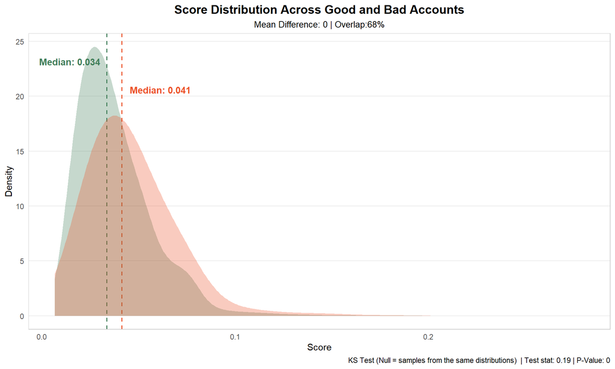

```r
# Calculate score distribution plot by target with enhanced visualization
score_data <- data.frame(
  Score = current_predictions,
  Target = factor(current_target, levels = c(0, 1), labels = c("Good", "Bad"))
)

# Calculate additional metrics
good_stats <- c(
  Mean = mean(current_predictions[current_target == 0]),
  Median = median(current_predictions[current_target == 0]),
  SD = sd(current_predictions[current_target == 0]),
  Q1 = quantile(current_predictions[current_target == 0], 0.25),
  Q3 = quantile(current_predictions[current_target == 0], 0.75)
)

bad_stats <- c(
  Mean = mean(current_predictions[current_target == 1]),
  Median = median(current_predictions[current_target == 1]),
  SD = sd(current_predictions[current_target == 1]),
  Q1 = quantile(current_predictions[current_target == 1], 0.25),
  Q3 = quantile(current_predictions[current_target == 1], 0.75)
)

# Calculate overlap coefficient (area of overlap divided by total area)
good_density <- density(current_predictions[current_target == 0], adjust = 3)
bad_density <- density(current_predictions[current_target == 1], adjust = 3)

# Create a common grid for both densities
grid <- seq(min(good_density$x, bad_density$x),
            max(good_density$x, bad_density$x),
            length.out = 1000
)

# Interpolate densities on the common grid
good_dens_interp <- approx(good_density$x, good_density$y, grid, rule = 2)$y
bad_dens_interp <- approx(bad_density$x, bad_density$y, grid, rule = 2)$y

# Calculate overlap coefficient (area of overlap divided by total area)
overlap_area <- sum(pmin(good_dens_interp, bad_dens_interp)) * (grid[2] - grid[1])
total_area <- sum(good_dens_interp + bad_dens_interp - pmin(good_dens_interp, bad_dens_interp)) * (grid[2] - grid[1])
overlap_coefficient <- overlap_area / total_area

# Calculate separation metrics
separation <- data.frame(
  Metric = c("Mean Difference", "Median Difference", "KS Statistic", "Overlap"),
  Value = c(
    bad_stats["Mean"] - good_stats["Mean"],
    bad_stats["Median"] - good_stats["Median"],
    ks.test(
      current_predictions[current_target == 0],
      current_predictions[current_target == 1]
    )$statistic,
    overlap_coefficient
  )
)

test_results <- ks.test(
  current_predictions[current_target == 0],
  current_predictions[current_target == 1]
)

# Create enhanced plot with ggplot2
ggplot(score_data, aes(x = Score)) +

  # Add median lines (with different line type)
  geom_vline(
    xintercept = good_stats["Median"],
    color = "#3F7D58",
    linetype = "dashed",
    size = 0.7
  ) +
  geom_vline(
    xintercept = bad_stats["Median"],
    color = "#EC5228",
    linetype = "dashed",
    size = 0.7
  ) +

  # Add annotations for means
  annotate("text",
           x = good_stats["Median"] - good_stats["Median"]/10,
           y = max(density(current_predictions)$y) * 0.9,
           label = paste0("Median: ", round(good_stats["Median"], 3)),
           color = "#3F7D58",
           hjust = 1,
           fontface = "bold"
  ) +
  annotate("text",
           x = bad_stats["Median"] + bad_stats["Median"]/10,
           y = max(density(current_predictions)$y) * 0.8,
           label = paste0("Median: ", round(bad_stats["Median"], 3)),
           color = "#EC5228",
           hjust = 0,
           fontface = "bold"
  ) +

  # Add area shading for overlap
  geom_area(
    stat = "density",
    data = score_data[score_data$Target == "Good", ],
    aes(y = ..density..),
    fill = "#3F7D58",
    alpha = 0.3,
    adjust = 3
  ) +
  geom_area(
    stat = "density",
    data = score_data[score_data$Target == "Bad", ],
    aes(y = ..density..),
    fill = "#EC5228",
    alpha = 0.3,
    adjust = 3
  ) +

  # Customize colors
  scale_fill_manual(values = c("Good" = "#3F7D58", "Bad" = "#EC5228")) +

  # Add labels and title
  labs(
    title = "Score Distribution Across Good and Bad Accounts",
    subtitle = paste0(
      "Mean Difference: ", round(separation$Value[1], 1),
      " | Overlap:", round(overlap_coefficient, 2) * 100, "%"
    ),
    x = "Score",
    y = "Density",
    caption = paste(
      "KS Test (Null = samples from the same distributions)",
      " | Test stat:", round(test_results$statistic, 2),
      "| P-Value:", round(test_results$p.value, 9)
    )
  ) +

  # Apply theme
  theme_minimal() +
  theme(
    plot.title = element_text(face = "bold", hjust = 0.5, size = 14),
    plot.subtitle = element_text(hjust = 0.5, size = 10),
    legend.position = "top",
    legend.title = element_blank(),
    panel.grid.minor = element_blank(),
    panel.grid.major.x = element_blank(),
    panel.border = element_rect(color = "grey80", fill = NA, size = 0.5)
  )
```

# Variable Directional Impact Analysis

This section analyzes how changes in each input variable affect the model’s predictions, helping understand the directional relationships and their stability over time.

```r
# Function to calculate binned analysis
analyze_variable_impact <- function(data, variable, pred_var, bins = 10) {

  # Convert data to data.frame
  df <- as.data.frame(data)

  # Ensure numeric
  df[[variable]] <- as.numeric(df[[variable]])
  df[[pred_var]] <- as.numeric(df[[pred_var]])

  # Remove NA values
  df <- df[!is.na(df[[variable]]) & !is.na(df[[pred_var]]), ]

  # Create bins
  breaks <- quantile(df[[variable]], probs = seq(0, 1, length.out = bins + 1), na.rm = TRUE)
  breaks <- unique(breaks)

  df$bin <- cut(df[[variable]], breaks = breaks, include.lowest = TRUE)

  # Calculate statistics by bin
  impact_df <- df %>%
    group_by(bin) %>%
    dplyr::summarise(
      avg_pred = mean(get(pred_var), na.rm = TRUE),
      count = n(),
      min_val = min(get(variable), na.rm = TRUE),
      max_val = max(get(variable), na.rm = TRUE)
    ) %>%
    mutate(
      bin_label = sprintf("%.2f - %.2f", min_val, max_val),
      pct_population = count / sum(count) * 100
    )

  return(impact_df)
}

# Function to create impact visualization
plot_variable_impact <- function(current_impact, reference_impact, variable, cor_current, cor_reference) {
  # Create plot
  p <- ggplot() +
    geom_line(data = current_impact, aes(x = as.numeric(bin), y = avg_pred, color = "Current"), size = 1) +
    geom_point(data = current_impact, aes(x = as.numeric(bin), y = avg_pred, size = pct_population, color = "Current")) +
    geom_line(data = reference_impact, aes(x = as.numeric(bin), y = avg_pred, color = "Reference"), size = 1, linetype = "dashed") +
    geom_point(data = reference_impact, aes(x = as.numeric(bin), y = avg_pred, size = pct_population, color = "Reference")) +
    scale_color_manual(values = c("Current" = "#EC5228", "Reference" = "#3F7D58")) +
    scale_size_continuous(name = "% Population", range = c(2, 6)) +
    labs(
      title = variable,
      subtitle = sprintf("Correlation with prediction: Current = %.3f, Reference = %.3f",
                         cor_current, cor_reference),
      x = "Variable Bins (Low to High)",
      y = "Average Prediction",
      color = "Period"
    ) +
    theme_minimal() +
    theme(
      plot.title = element_text(face = "bold"),
      legend.position = "top"
    )

  return(p)
}
```

## Impact Analysis

**Note** - if variables do not have sufficient unique values, charts might not populate.